# Differences-in-Differences Causal Analysis of a Fishery Management Reform in Peru

Author

Natalie Smith

Published

October 10, 2021

# 1 Background:

In 2009, the Individual Vessel Quota (IVQ) system was implemented for Peruvian anchoveta fisheries in the North-Central zone to enhance stock monitoring, alleviate fishing pressure, and incentivize sustainable practices. This policy allocated each vessel a percentage of the Total Allowable Catch (TAC) based on its historical performance, while also varying seasonally based on biological, weather, and climate variables. Additionally, the system introduced several additional measures, including a seasonal tax on harvested tons, satellite surveillance for better compliance, and designated docks to weight the landing.

We aim to assess whether the IVQ had a causal effect on harvest levels, using the South zone, which was not subject to policy, as a counterfactual. Through a differences-in-differences (DiD) analysis, we will compare the North-Central zone (affected by the IVQ) and the South zone (unaffected) before and after the policy’s implementation. This approach will help us determine whether the IVQ resulted in changes in fishery landings while accounting for external factors influencing both zones.

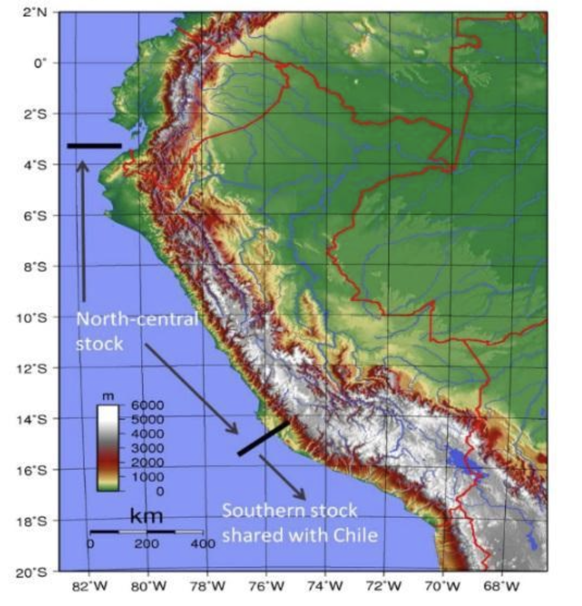

Figure 1: Arias Schreiber and Halliday, 2013

# 2 Prepare Libraries & Data:

```r
library(tidyverse)
library(knitr)
library(here)
library(kableExtra)
```

```r
# Load the data using here package
anchovy_data <- read_csv(here("data", "df_peru.csv"))
```

# 3 Employ Diff-in-Diff Analysis:

We first created a new variable called ‘log_landing’ by taking the logarithm of the ‘landing’ variable. Then, we created two dummy variables: one named ‘post’ to indicate when the treatment began (1 for 2009 and after, 0 for before), and another variable called ‘north’ to identify the group exposed to the treatment (1 for NC and 0 for S). Next, we created an interaction between these variables called ‘did’ (differences-in-differences). This interaction variable is equal to 1 only for observations that are both in the treatment group and occur after the treatment started. Finally, we performed a linear regression based on the functional form below:

$$Landing_{tg} = \alpha + \beta_0 North_{g} + \beta_1Post_{t} + \beta_2North_{g}Post_{t} + \epsilon_{tg}$$

```r
#Create a new variable called log_landing by taking the log of the landings variable
log_anchovy_data <- anchovy_data %>%
  mutate(log_landing = log(landing))

#Create a dummy variable called 'post' to indicate when the treatment started (year 2009)
log_anchovy_data <- log_anchovy_data %>%
  mutate(post = ifelse(year >= 2009, 1, 0))

#Create a dummy variable called 'north' to identify the group (zone) exposed to the treatment (CN)
log_anchovy_data <- log_anchovy_data %>%
  mutate(north = ifelse(zone=="CN", 1, 0))

#Create the interaction between the time the treatment started and the treatment group
log_anchovy_data <- log_anchovy_data %>%
  mutate(did = post*north) #where its after 2009 and its the north zone

#Run a linear regression using the functional form proposed above
lm_anchovy <- lm(log_landing ~ north + post + did, data = log_anchovy_data)
# summary(lm_anchovy)
```

```r
kable(summary(lm_anchovy)$coefficients, digits = 3,
      col.names = c("Coefficient", "Std. Error", "T-value", "Pr(>|t|)"),
      caption = "Linear Model Coefficients for Anchovy Landings")
```

Linear Model Coefficients for Anchovy Landings

|  | Coefficient | Std. Error | T-value | Pr(>\|t\|) |
| --- | --- | --- | --- | --- |
| (Intercept) | 4.603 | 0.015 | 311.650 | 0 |
| north | 0.311 | 0.017 | 17.824 | 0 |
| post | 0.171 | 0.021 | 8.202 | 0 |
| did | -0.176 | 0.025 | -7.144 | 0 |

# 4 Interpretation of the DiD Coefficient:

# 5 Analysis

### 5.0.1 *Question 1:*

*We used the South as a counterfactual region because the policy wasn’t applied there. Describe one or more possible problems with this assumption.*

There could be other influential factors besides time and policy, such as environmental variables, advancements in fishing technology, and fluctuations in demand for fish. Additionally, natural population dynamics, like stochastic fluctuations, might also contribute to changes in fish populations, independent of the policy.

### 5.0.2 *Question 2:*

*To analyze whether the counterfactual makes sense, take the mean of log_landing before and after the policy for each zone. Show your results in a table.*

```r
#take the mean of log_landing before and after the policy for each zone
mean_anchovy_data <- log_anchovy_data %>%
  group_by(zone, post) %>%
  summarize(mean_log_landing = mean(log_landing))

#summarize in a kable table
kable(mean_anchovy_data, digits = 3,
      col.names = c("Zone", "Post", "Mean Log Landing"),
      caption = "Mean Log Landing Before and After the Policy for Each Zone")
```

Mean Log Landing Before and After the Policy for Each Zone

| Zone | Post | Mean Log Landing |
| --- | --- | --- |
| CN | 0 | 4.914 |
| CN | 1 | 4.909 |
| S | 0 | 4.603 |
| S | 1 | 4.774 |

### 5.0.3 *Question 3:*

*Does the parallel trends assumption seem to hold? What are the implications of this for your analysis*?